# lab06-report

## Lab 6

### 500909196

### 10/25/19

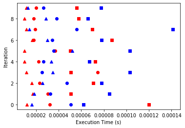

```python
from sorting import *
timingTest()
```

Here, we run an experiment comparing the execution time of two versions of quicksort. The first is the standard quicksort (shown in red), and the other uses the median-of-three method to determine the pivot point (shown in blue). We test both quicksorts on three separate lists: a short one with 4 terms (triangle), a medium one with 9 terms (circle), and a large one with 25 terms (square).

We repeat these tests 10 times for accuracy, and we can see that the median-of-three method is almost always slower than the original.

What results would we get with an even larger list, though?

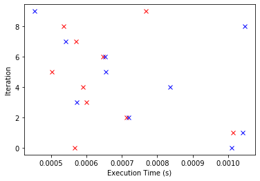

```python
from sorting import *
timingTest2()
```

Here, we do the same experiment again, but with a list of 100 elements. Still, the results are all over the place. There are a few instances where the two functions have a similar execution time, but other times the differences are substantial.

These differences, however, are only fractions of a millisecond, and the average person staring at a computer screen isn't going to notice much of a difference in speed between the two methods.